# Discrete state space models in survival analysis: a particle filter application

## dummy slide

# Talk overview

Motivation and model.

Generalized two-filter smoother and an extension.

Example.

# Motivation

Longitudinal data set up to time $d$ where individuals are censored or cease to exist.

Expect that slopes or the intercept may vary.

Want to extrapolate beyond time $d$.

Methods are available in the R package `dynamichazard`.

# Example: Firm defaults

Each month we have the firms that are listed in the prior month for a total of $d$ months.

A typical model is a logistic regression conditional on having survived up to time $t - 1$.

Firms may be censored (merged, split etc.) or default.

The intercept may be non-constant (unobservable macro effect).

Some of the slopes may vary.

# Model

Observational equation

$$y_{it} \sim g(\cdot \vert \eta_{it}), \qquad
\eta_{it} = \bea^\top\vec{x}_{it} + (\mat{R}^\top\alf_t)^\top\vec{z}_{it} +
o_{it}$$

$t=1,\dots,d$, $i\in \mathcal{R}_t$, $g(\cdot \vert \eta_{it})$ is from the exponential family

$\alf_t$ is an unobservable with dynamics

$$\begin{split}
\alf_t = \mat{F}(\thet) \alf_{t-1} + \mat{R}\epslon_t,
\qquad & \epslon_t \sim N(\vec{0}, \mat{Q}) \\
& \alf_0 \sim N(\vec{a}_0, \mat{Q}_0)
\end{split}$$

## Example: conditional piece-wise constant exponential distribution

$T_i\in[0,\infty)$ is the stop time and likelihood when $T_i > t - 1$

$$\begin{split}
y_{it} &= 1_{\{T_i \in (t-1, t]\}}, \quad o_{it} = \log(\min\{t, T_i\} - (t - 1)) \\
P(y_{it} \vert \eta_{it}) &= \exp(y_{it}\eta_{it} - \exp(\eta_{it}))
\end{split}$$

with AR(2) process

$$\begin{split}
\vxi_t &= \mat{R}^\top \alf_t, \quad
\qquad \alf_t = (\vxi_t^\top, \vxi_{t - 1}^\top)^\top \\
\mat{R} &=
\begin{pmatrix} \mat{I}_r & \mat{0} \\ \mat{0} & \mat{0} \end{pmatrix},
\qquad \mat{F} =
\begin{pmatrix} \Thet_1 & \Thet_2 \\ \mat{I}_r & \mat{0} \end{pmatrix}
\end{split}$$

# Particle filtering and smoothing

Idea of generalized two-filter smoother

- Run a forward particle filter.
- Run a backward particle filter.
- Combine the two.

## Foward particle filter

Idea: sequential importance sampling

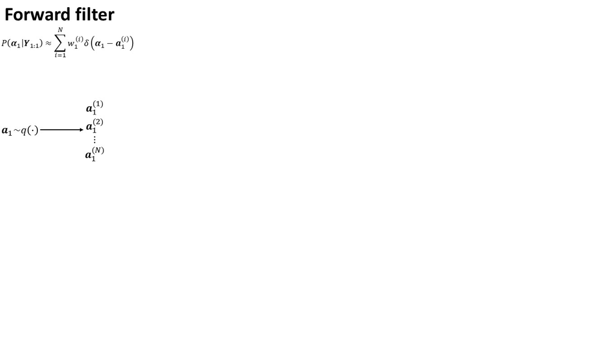

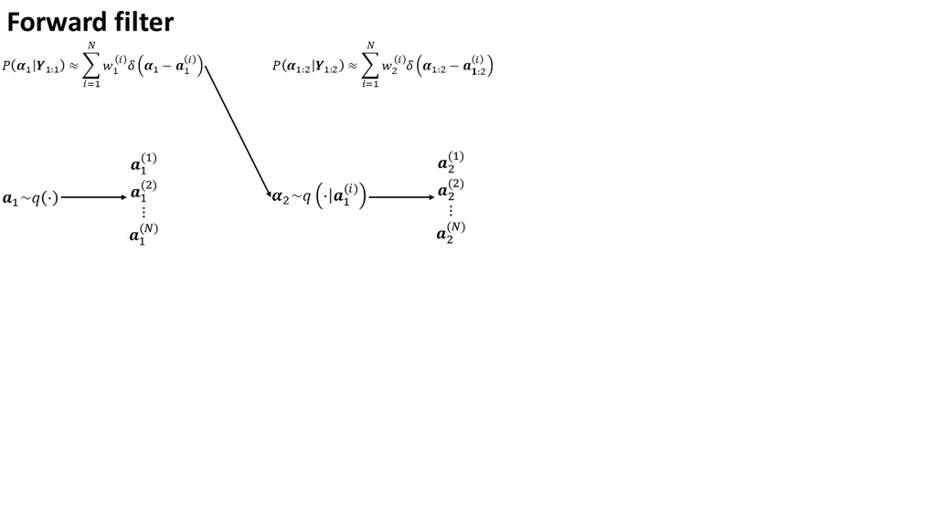

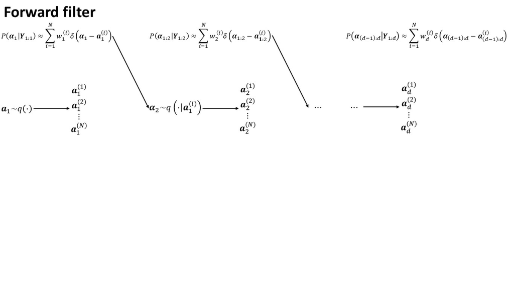

## Issue

Want smoothed approximation

$$P(\alf_{(t-1):t} \vert \vec{Y}_{1:d})$$

and not

$$P(\alf_{(t-1):t} \vert \vec{Y}_{1:t})$$

## Generalized two sample filter

Need backward filter approximation

$$P(\alf_t \vert \vec{Y}_{t:d}) \propto \gamma_t(\alf_t)P(\vec{Y}_{t:d} \vert \alf_t )$$

where the artificial probability distributions is

$$\begin{split} \gamma_t(\alf_t) &=
\int_{\mathbb{R}^q} f(\alf_t\vert\alf_{t-1})
\gamma_{t - 1}(\alf_{t-1})d\alf_{t-1} \\
& = N(\mat{F}(\thet)^{t}\vec{a}_0, \mat{Q}_0+\mat{F}(\thet)^{t\top}\mat{Q}\mat{F}(\thet)^{t})
\end{split}$$

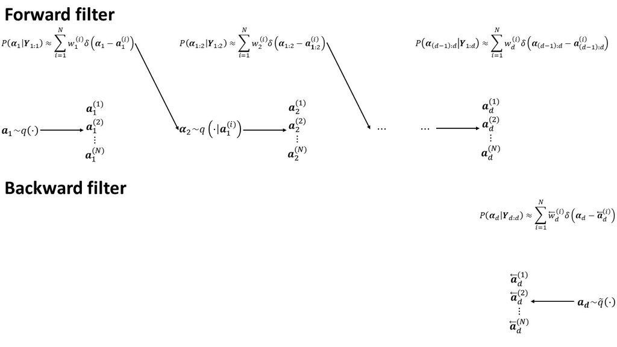

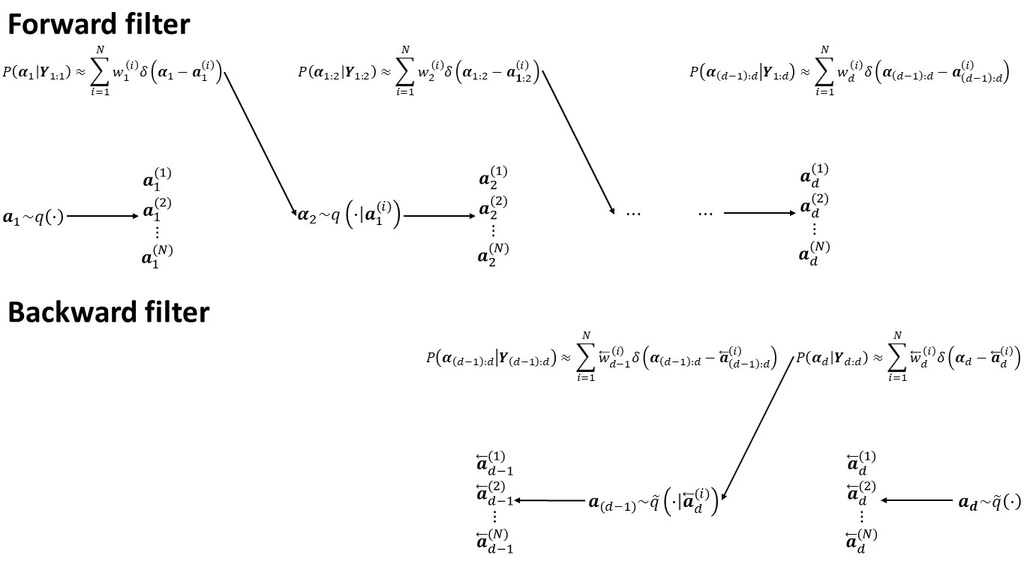

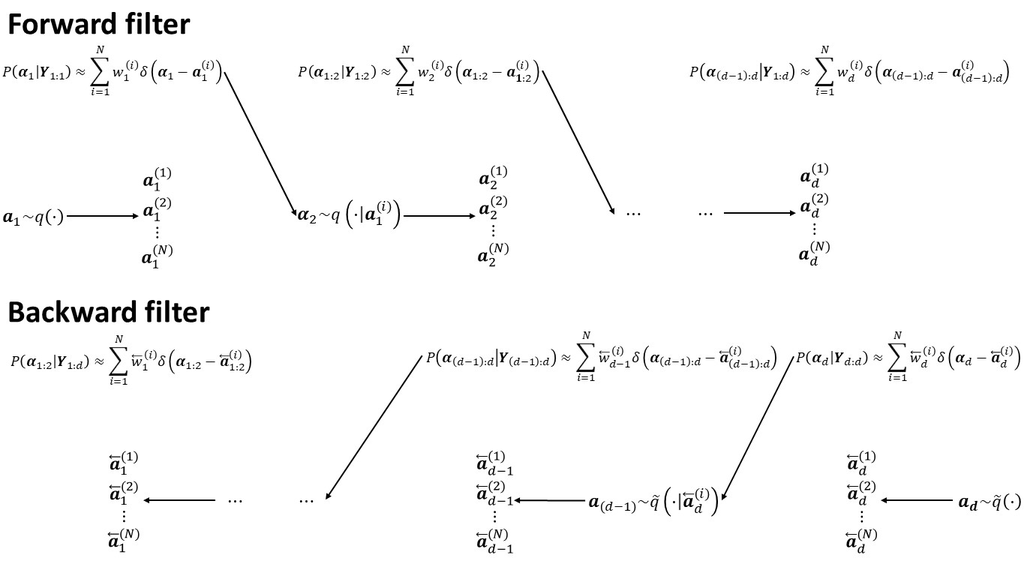

## Combining: Briers, Doucet, and Maskell (2009)

Idea: re-weight particles using

$$\hat{w}^{(i)}_t =
\frac{\overleftarrow{w}_t^{(i)}}{\gamma_t(\overleftarrow{\alf}_t^{(i)})}
\sum_{j = 1}^N f(
\overleftarrow{\alf}_t^{(i)} \vert
\alf_{t - 1}^{(j)})w_{t - 1}^{(j)}$$

Issue: $\bigO{N^2}$

## Combining: Fearnhead, Wyncoll, and Tawn (2010)

Sample $i_k$ using $\overleftarrow{w}_{t + 1}^{(1)}, \dots \overleftarrow{w}_{t + 1}^{(N)}$.

Sample $j_k$ using $w_{t - 1}^{(1)}, \dots, w_{t - 1}^{(N)}$.

Sample $\hat{\alf}_t^{(k)} \sim \hat{q}(\cdot \vert \overleftarrow{\alf}_{t + 1}^{(i_k)}, \alf_{t - 1}^{(j_k)})$.

Set

$$\hat{w}_t^{(k)} \propto \frac{
f(\hat{\alf}_t^{(k)} \vert \alf_{t-1}^{(j_k)})
g(\vec{y}_t\vert\hat{\alf}_t^{(k)})
f(\overleftarrow{\alf}_{t + 1}^{(j_k)} \vert \hat{\alf}_t^{(k)})
}{
\hat{q}(\hat{\alf}_{t + 1}^{(k)} \vert \overleftarrow{\alf}_{t + 1}^{(i_k)}, \alf_{t - 1}^{(j_k)})
\gamma_{t + 1}(\overleftarrow{\alf}_{t + 1}^{(i_k)})
}$$

# Example: Randomized clinical trial

Longitudinal data with 467 patients and 188 deaths with a cohort followed for around 20 months.

- `drug`: factor for the used drug.
- `AZT`: whether intolerant to AZT or AZT failed.
- `prevOI`: had opportunistic AIDS infection at $t=0$.

See e.g., Guo and Carlin (2004) for an analysis.

## Constant hazard model

```r
sur_fit <- survreg(
  Surv(stop, event) ~ AZT + gender + drug + prevOI, aids,
  dist= "exponential")
summary(sur_fit)$table[, c("Value", "Std. Error", "p")]
```

```
#R>                Value Std. Error                   p
#R>  (Intercept)  4.2346     0.2897             < 1E-16
#R>  AZTfailure  -0.1649     0.1629  0.3115384496036516
#R>  gendermale   0.3388     0.2451  0.1669604211575632
#R>  drugddI     -0.2080     0.1464  0.1552720002242361
#R>  prevOIAIDS  -1.2390     0.2264  0.0000000440474652
```

## Cox proportional hazards models

```r
cox_fit <- coxph(
  Surv(stop, event) ~ AZT + gender + drug + prevOI, aids)
summary(cox_fit)$coefficients[, c("coef", "z", "Pr(>|z|)")]
```

```
#R>                coef       z      Pr(>|z|)
#R>  AZTfailure  0.1575  0.9635 0.33529247356
#R>  gendermale -0.3419 -1.3928 0.16367711695
#R>  drugddI     0.2170  1.4818 0.13839710893
#R>  prevOIAIDS  1.2920  5.6924 0.00000001252
```

## Cumulative hazard function

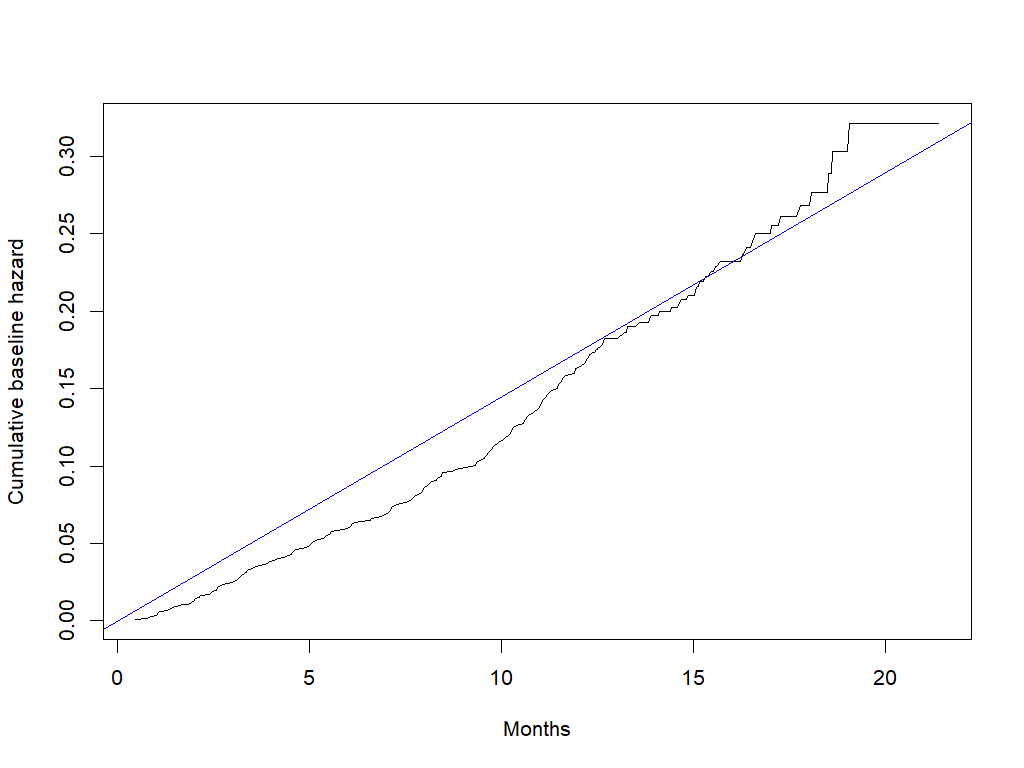

Blue: constant hazard model. Black: non-parametric baseline hazard from cox model.

# $\bigO{N^2}$ smoother

```r
set.seed(33706242)
system.time(
  fit_Brier <- PF_EM(
    Surv(stop, event) ~ ddFixed(AZT) + ddFixed(gender) + ddFixed(drug) +
      ddFixed(prevOI),
    aids, model = "exponential", by = .5, max_T = 20, Q = .33, Q_0 = 1,
    id = aids$patient,
    control = PF_control(
      n_threads = 4, N_fw_n_bw = 1000, N_first = 1000,
      N_smooth = 1,                  # Does not matter with Brier_O_N_square
      smoother = "Brier_O_N_square", # Select smoother
      eps = .001, n_max = 100)))
```

```
#R>     user  system elapsed
#R>   2406.9   369.1   893.1
```

# $\bigO{N^2}$ smoother

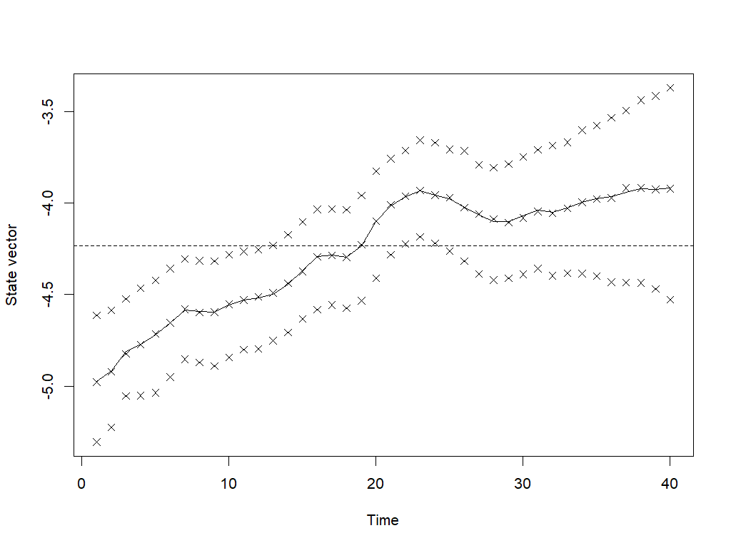

Outer crosses are 90% confidence limits, inner crosses are the mean, dashed line is the log of the baseline hazard in the exponential distributed model.

# $\bigO{N^2}$ smoother

```r
mean(fit_Brier$effective_sample_size$smoothed_clouds)
drop(sqrt(fit_Brier$Q))
fit_Brier$fixed_effects
fit_Brier$n_iter
```

```
#R>  [1] 576.3
#R>  [1] 0.1373
#R>  [1]  0.1574 -0.3055  0.2236  1.3215
#R>  [1] 55
```

# $\bigO{N^2}$ smoother

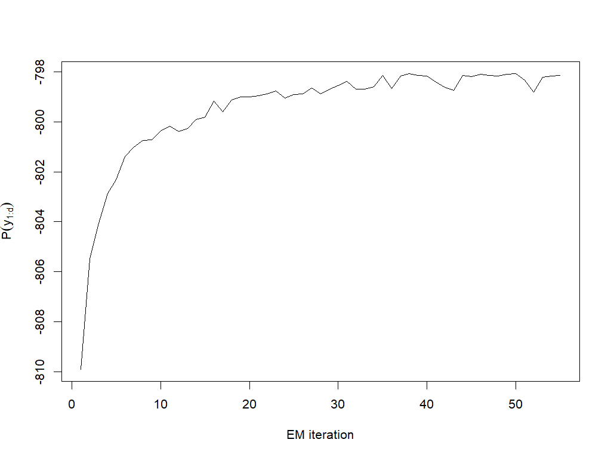

# $\bigO{N}$ smoother

```r
set.seed(33706242)
system.time(
  fit_Fearn <- PF_EM(
    Surv(stop, event) ~ ddFixed(AZT) + ddFixed(gender) + ddFixed(drug) +
      ddFixed(prevOI),
    aids, model = "exponential", by = .5, max_T = 20, Q = .33, Q_0 = 1,
    id = aids$patient,
    control = PF_control(
      n_threads = 4, N_fw_n_bw = 250, N_first = 1000,
      N_smooth = 5000,            # Now it matters
      smoother = "Fearnhead_O_N", # Select smoother
      eps = .001, n_max = 100)))
```

```
#R>     user  system elapsed
#R>   1605.0   754.8   704.4
```

# $\bigO{N}$ smoother

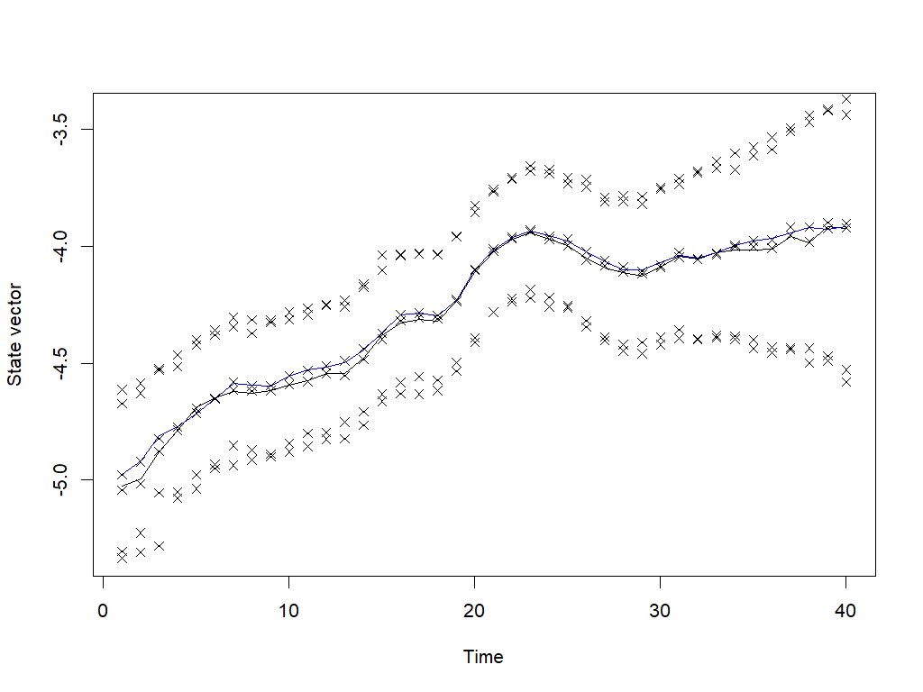

Blue: $\bigO{N^2}$ smoother. Black: $\bigO{N}$ smoother.

# $\bigO{N}$ smoother

```r
mean(fit_Fearn$effective_sample_size$smoothed_clouds)
drop(sqrt(fit_Fearn$Q))
fit_Fearn$n_iter
```

```
#R>  [1] 2533
#R>  [1] 0.138
#R>  [1] 48
```

# Two random effects

```r
set.seed(33706242)
system.time(
  fit_Fearn_two <- PF_EM(
    Surv(stop, event) ~ ddFixed(AZT) + ddFixed(gender) + drug + ddFixed(prevOI),
    aids, model = "exponential", by = .5, max_T = 20,
    Q = diag(.33, 2), Q_0 = diag(1, 2),
    id = aids$patient,
    control = PF_control(
      n_threads = 4, N_fw_n_bw = 250, N_first = 1000,
      N_smooth = 5000,  smoother = "Fearnhead_O_N", eps = .001, n_max = 100)))
```

```
#R>     user  system elapsed
#R>     2916    1387    1480
```

# Intercept

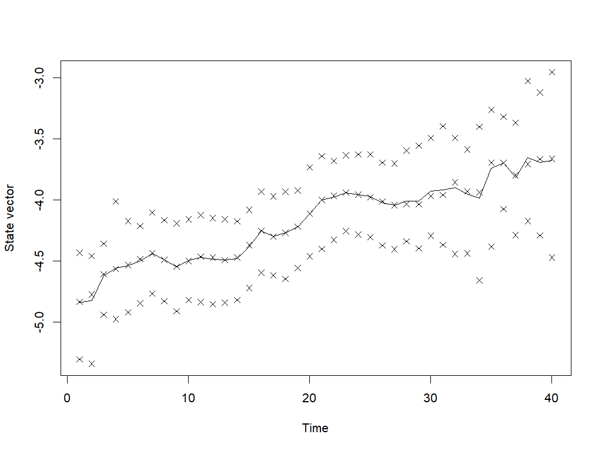

# `Drug` dummy

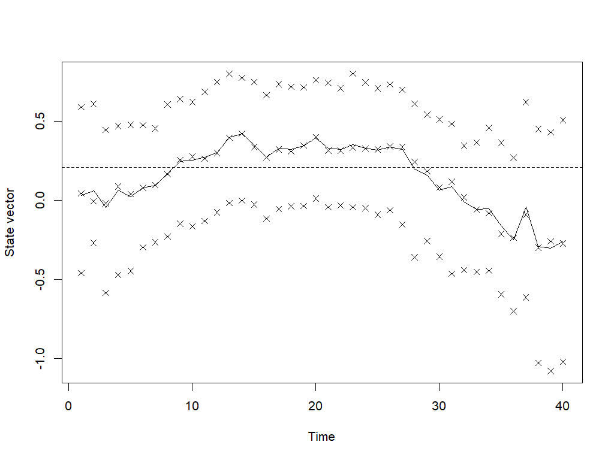

Dashed line is the coefficient in the exponential distributed model.

# Co-variance matrix

```r
fit_Fearn_two$Q
```

```
#R>           [,1]     [,2]
#R>  [1,]  0.02292 -0.01339
#R>  [2,] -0.01339  0.02464
```

```r
cov2cor(fit_Fearn_two$Q)
```

```
#R>          [,1]    [,2]
#R>  [1,]  1.0000 -0.5633
#R>  [2,] -0.5633  1.0000
```

```r
mean(fit_Fearn_two$effective_sample_size$smoothed_clouds)
```

```
#R>  [1] 992
```

# Comments

Ignored re-sampling, choice of proposal distribution and more. Different options are available in `dynamichazard` packages.

Only supports a random walk. More general models is available soon.

Code on [github.com/boennecd/Talks](https://github.com/boennecd/Talks/tree/master/Nordstat2018/nordstat18) and presentation on rpubs.com/boennecd/Nordstat2018.

# References

Briers, Mark, Arnaud Doucet, and Simon Maskell. 2009. “Smoothing Algorithms for State–space Models.” *Annals of the Institute of Statistical Mathematics* 62 (1): 61. doi:10.1007/s10463-009-0236-2.

Fearnhead, Paul, David Wyncoll, and Jonathan Tawn. 2010. “A Sequential Smoothing Algorithm with Linear Computational Cost.” *Biometrika* 97 (2). [Oxford University Press, Biometrika Trust]: 447–64. http://www.jstor.org/stable/25734097.

Guo, Xu, and Bradley P. Carlin. 2004. “Separate and Joint Modeling of Longitudinal and Event Time Data Using Standard Computer Packages.” *The American Statistician* 58 (1). [American Statistical Association, Taylor & Francis, Ltd.]: 16–24. http://www.jstor.org/stable/27643494.